# STAT646 Final Exam

# Multiple choices

1-c, 2-b, 3-a, 4-e, 5-e, 6-e

# Problem 7

### Part i.

12882 Child, 12877 Father, 12878 Mother, 12891 Maternal grandfather, 12892 Maternal grandmother

### Part ii.a

```r
PP <- read.table("PPallAA.txt", header = T)
```

Total number inherited from the father (_F)

```r
ref_a <- sum(PP$NA12882_PP_F>0.9 & PP$NA12877_PP_F>0.9)
var_a <- sum(PP$NA12882_PP_F<0.1 & PP$NA12877_PP_F<0.1)
ref_a+var_a
```

```
## [1] 10898
```

### Part ii.b

Total number inherited from the mother (_F)

```r
ref_b <- sum(PP$NA12882_PP_F>0.9 & PP$NA12878_PP_F>0.9)
var_b <- sum(PP$NA12882_PP_F<0.1 & PP$NA12878_PP_F<0.1)
ref_b+var_b
```

```
## [1] 11277
```

### Part ii.c

Total number inherited from the mother, who inherited from the maternal grandmother (_F)

```r
ref_c <- sum(PP$NA12882_PP_F>0.9 & PP$NA12878_PP_F>0.9 & PP$NA12892_PP_F>0.9)
var_c <- sum(PP$NA12882_PP_F<0.1 & PP$NA12878_PP_F<0.1 & PP$NA12892_PP_F<0.1)
ref_c+var_c
```

```
## [1] 8103
```

### Part iii.a

Total number inherited from the father (_S)

```r
ref_a_s <- sum(PP$NA12882_PP_S>0.9 & PP$NA12877_PP_S>0.9)
var_a_s <- sum(PP$NA12882_PP_S<0.1 & PP$NA12877_PP_S<0.1)
ref_a_s+var_a_s
```

```
## [1] 10898
```

### Part iii.b

Total number inherited from the mother (_S)

```r
ref_b_s <- sum(PP$NA12882_PP_S>0.9 & PP$NA12878_PP_S>0.9)
var_b_s <- sum(PP$NA12882_PP_S<0.1 & PP$NA12878_PP_S<0.1)
ref_b_s+var_b_s
```

```
## [1] 11275
```

### Part iii.c

Total number inherited from the mother, who inherited from the maternal grandmother (_S)

```r
ref_c_s <- sum(PP$NA12882_PP_S>0.9 & PP$NA12878_PP_S>0.9 & PP$NA12892_PP_S>0.9)
var_c_s <- sum(PP$NA12882_PP_S<0.1 & PP$NA12878_PP_S<0.1 & PP$NA12892_PP_S<0.1)
ref_c_s+var_c_s
```

```
## [1] 8098
```

Checking for overlaps for the Venn Diagram

```r
a<-sum(PP$NA12882_PP_S>0.9 & PP$NA12877_PP_S>0.9&PP$NA12882_PP_F>0.9 &
      PP$NA12877_PP_F>0.9)
b<-sum(PP$NA12882_PP_S<0.1 & PP$NA12877_PP_S<0.1&PP$NA12882_PP_F<0.1 &
      PP$NA12877_PP_F<0.1)

c<-sum(PP$NA12882_PP_S>0.9 & PP$NA12878_PP_S>0.9&PP$NA12882_PP_F>0.9 &
      PP$NA12878_PP_F>0.9)
d<-sum(PP$NA12882_PP_S<0.1 & PP$NA12878_PP_S<0.1&PP$NA12882_PP_F<0.1 &
      PP$NA12878_PP_F<0.1)

e<-sum(PP$NA12882_PP_F>0.9 & PP$NA12878_PP_F>0.9 & PP$NA12892_PP_F>0.9&
      PP$NA12882_PP_S>0.9 & PP$NA12878_PP_S>0.9 & PP$NA12892_PP_S>0.9)
f<-sum(PP$NA12882_PP_F<0.1 & PP$NA12878_PP_F<0.1 & PP$NA12892_PP_F<0.1&
      PP$NA12882_PP_S<0.1 & PP$NA12878_PP_S<0.1 & PP$NA12892_PP_S<0.1)
```

Plot Venn diagrams

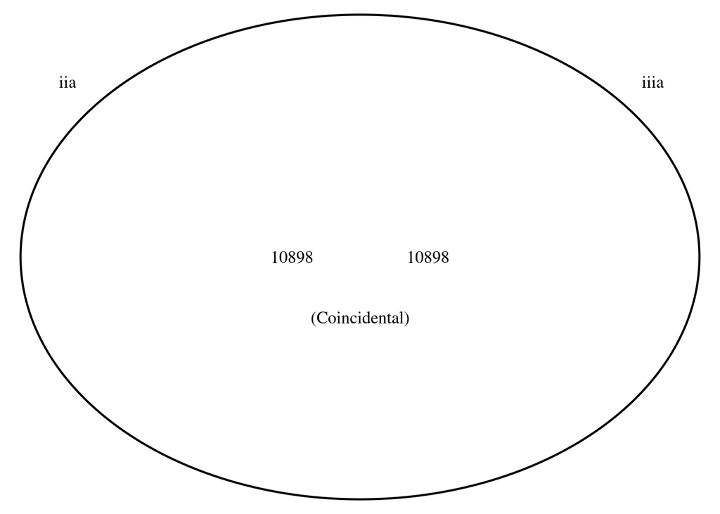

```
## (polygon[GRID.polygon.1], polygon[GRID.polygon.2], text[GRID.text.3], text[GRID.text.4], text[GRID.text.5], text[GRID.text.6], text[GRID.text.7])
```

```r
library(VennDiagram)
grid.newpage()
draw.pairwise.venn(area1 = 10898, area2 = 10898, cross.area = 10898, category = c("iia", "iiia"))
```

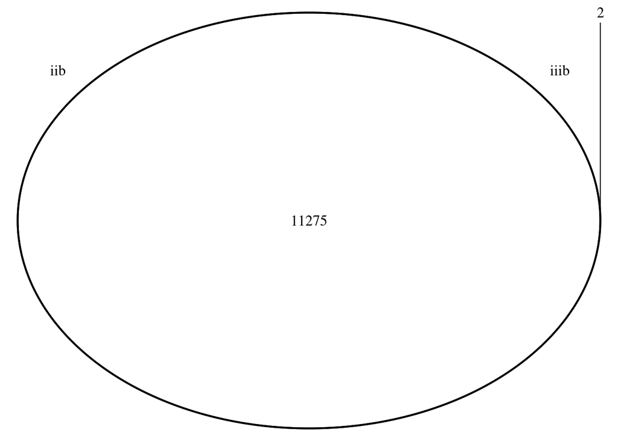

```
## (polygon[GRID.polygon.8], polygon[GRID.polygon.9], polygon[GRID.polygon.10], polygon[GRID.polygon.11], text[GRID.text.12], text[GRID.text.13], lines[GRID.lines.14], text[GRID.text.15], text[GRID.text.16])
```

```r
grid.newpage()
draw.pairwise.venn(area1 = 11277, area2 = 11275, cross.area = 11275, category = c("iib", "iiib"))
```

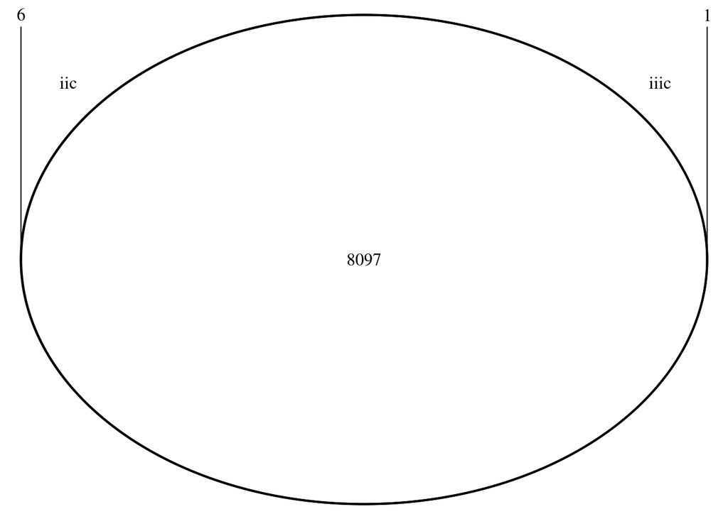

```
## (polygon[GRID.polygon.17], polygon[GRID.polygon.18], polygon[GRID.polygon.19], polygon[GRID.polygon.20], text[GRID.text.21], lines[GRID.lines.22], text[GRID.text.23], lines[GRID.lines.24], text[GRID.text.25], text[GRID.text.26], text[GRID.text.27])
```

```r
grid.newpage()
draw.pairwise.venn(area1 = 8103, area2 = 8098, cross.area = 8097, category = c("iic", "iiic"))
```

# Problem 8

### Part i

The package provides a RangedSummarizedExperiment object of read counts in genes for an RNA-Seq experiment on four human airway smooth muscle cell lines treated with dexamethasone. In the experiment, four primary human airway smooth muscle cell lines were treated with 1 micromolar dexamethasone for 18 hours. For each of the four cell lines, we have a treated and an untreated sample.

### Part ii

```r
library(DESeq2)
library(airway)
data("airway")
se <- airway
se$dex <- relevel(se$dex, "untrt")
```

Both cell type and treatment status

```r
dds <- DESeqDataSet(se, design = ~ cell + dex)
dds <- dds[ rowSums(counts(dds)) > 1, ]
dds <- DESeq(dds)
res <- results(dds)

topGene <- rownames(res)[which.min(res$padj)]
res <- res[-which.min(res$padj),]
topGene2 <- rownames(res)[which.min(res$padj)]
res <- res[-which.min(res$padj),]
topGene3 <- rownames(res)[which.min(res$padj)]
```

The top three genes with the lowest p-adj values

```r
topGene
```

```
## [1] "ENSG00000152583"
```

```r
topGene2
```

```
## [1] "ENSG00000165995"
```

```r
topGene3
```

```
## [1] "ENSG00000101347"
```

### Part iii

Treatment status only

```r
dds_2 <- DESeqDataSet(se, design = ~ dex)
dds_2 <- dds_2[ rowSums(counts(dds_2)) > 1, ]
dds_2 <- DESeq(dds_2)
res_2 <- results(dds_2)

topGene_2 <- rownames(res_2)[which.min(res_2$padj)]
res_2 <- res_2[-which.min(res_2$padj),]
topGene2_2 <- rownames(res_2)[which.min(res_2$padj)]
res_2 <- res_2[-which.min(res_2$padj),]
topGene3_2 <- rownames(res_2)[which.min(res_2$padj)]
```

The top three genes with the lowest p-adj values

```r
topGene_2
```

```
## [1] "ENSG00000152583"
```

```r
topGene2_2
```

```
## [1] "ENSG00000148175"
```

```r
topGene3_2
```

```
## [1] "ENSG00000179094"
```

### Part iv

Define a function used to plot a 6-panel figure

```r
multiplot <- function(..., plotlist=NULL, file, cols=1, layout=NULL) {
  library(grid)
  plots <- c(list(...), plotlist)
  numPlots = length(plots)
  if (is.null(layout)) {
    layout <- matrix(seq(1, cols * ceiling(numPlots/cols)),
                     ncol = cols, nrow = ceiling(numPlots/cols))
  }

  if (numPlots==1) {
    print(plots[[1]])

  } else {
    grid.newpage()
    pushViewport(viewport(layout = grid.layout(nrow(layout), ncol(layout))))

    for (i in 1:numPlots) {
      matchidx <- as.data.frame(which(layout == i, arr.ind = TRUE))
      print(plots[[i]], vp = viewport(layout.pos.row = matchidx$row,
                                      layout.pos.col = matchidx$col))
    }
  }
}
```

Graphs for both type and treatment status

```r
library("ggbeeswarm")
library("ggplot2")
geneCounts <- plotCounts(dds, gene = topGene, intgroup = c("dex","cell"),
                         returnData = TRUE)
p1_1 = ggplot(geneCounts, aes(x = dex, y = count, color = cell)) +
  scale_y_log10() +  geom_beeswarm(cex = 3)
geneCounts <- plotCounts(dds, gene = topGene2, intgroup = c("dex","cell"),
                         returnData = TRUE)
p1_2 = ggplot(geneCounts, aes(x = dex, y = count, color = cell)) +
  scale_y_log10() +  geom_beeswarm(cex = 3)
geneCounts <- plotCounts(dds, gene = topGene3, intgroup = c("dex","cell"),
                         returnData = TRUE)
p1_3 = ggplot(geneCounts, aes(x = dex, y = count, color = cell)) +
  scale_y_log10() +  geom_beeswarm(cex = 3)
```

Graphs for treatment status only

```r
geneCounts_2 <- plotCounts(dds_2, gene = topGene_2, intgroup = c("dex","cell"),
                         returnData = TRUE)
p2_1 = ggplot(geneCounts_2, aes(x = dex, y = count, color = cell)) +
  scale_y_log10() +  geom_beeswarm(cex = 3)
geneCounts_2 <- plotCounts(dds, gene = topGene2_2, intgroup = c("dex","cell"),
                         returnData = TRUE)
p2_2 = ggplot(geneCounts_2, aes(x = dex, y = count, color = cell)) +
  scale_y_log10() +  geom_beeswarm(cex = 3)
geneCounts_2 <- plotCounts(dds, gene = topGene3_2, intgroup = c("dex","cell"),
                         returnData = TRUE)
p2_3 = ggplot(geneCounts_2, aes(x = dex, y = count, color = cell)) +
  scale_y_log10() +  geom_beeswarm(cex = 3)
```

Plot a 6-panel figure using the multiplot function defined earlier. The top three graphs are for part ii. The bottom three graphs are for part iii.

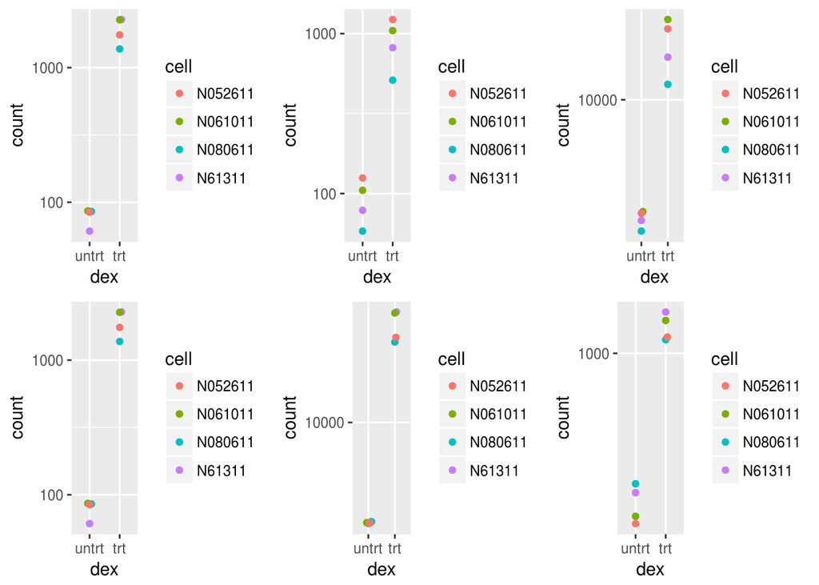

```r
multiplot(p1_1, p2_1, p1_2, p2_2, p1_3, p2_3 ,cols = 3)
```